# Part 2 Kira Plastinina Project

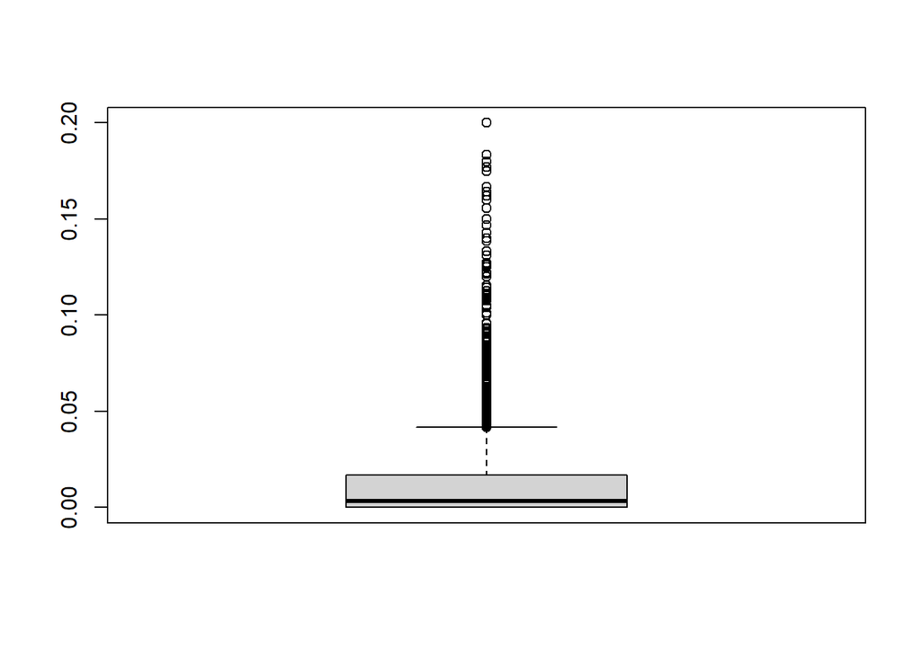

```r
boxplot(df$BounceRates)
```

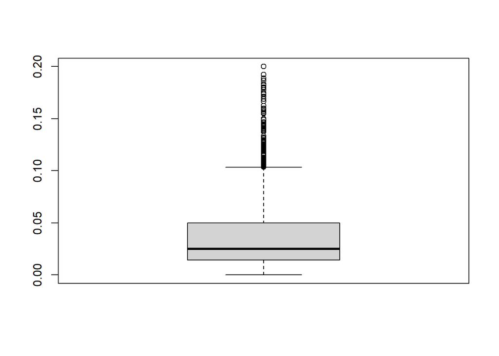

```r
boxplot(df$ExitRates)
```

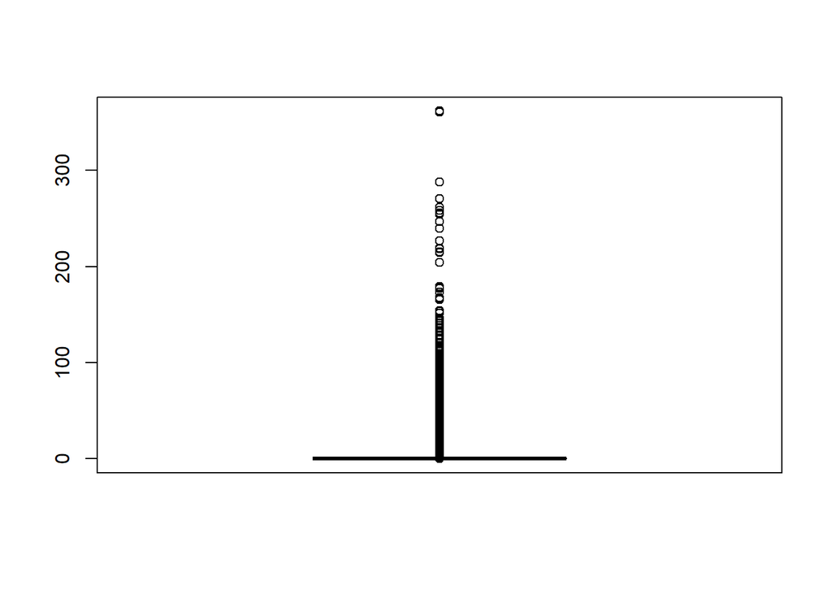

```r
boxplot(df$PageValues)
```

From the above box plot we have quite a number of outliers in the data set, however due to the details entailed in every attribute of the data these outliers are important for the project and will therefore not drop them.

# **EXPLORATORY DATA ANALYSIS**

### **1. Univariate Analysis**

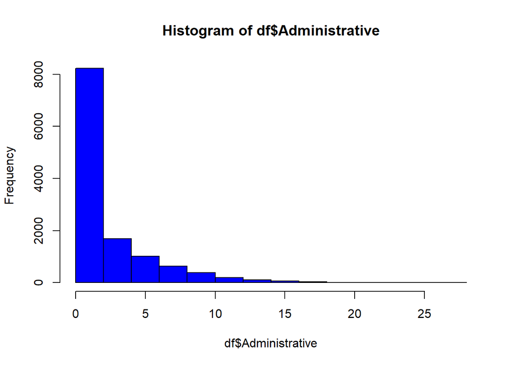

```r
hist(df$Administrative, col="blue")
```

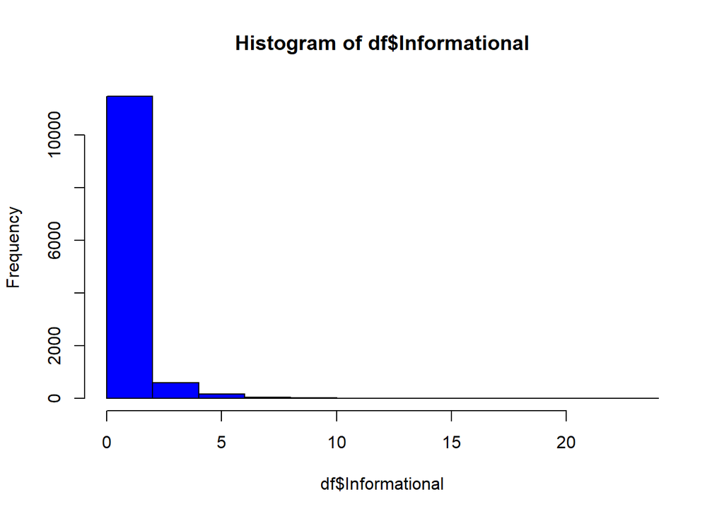

```r
hist(df$Informational, col="blue")
```

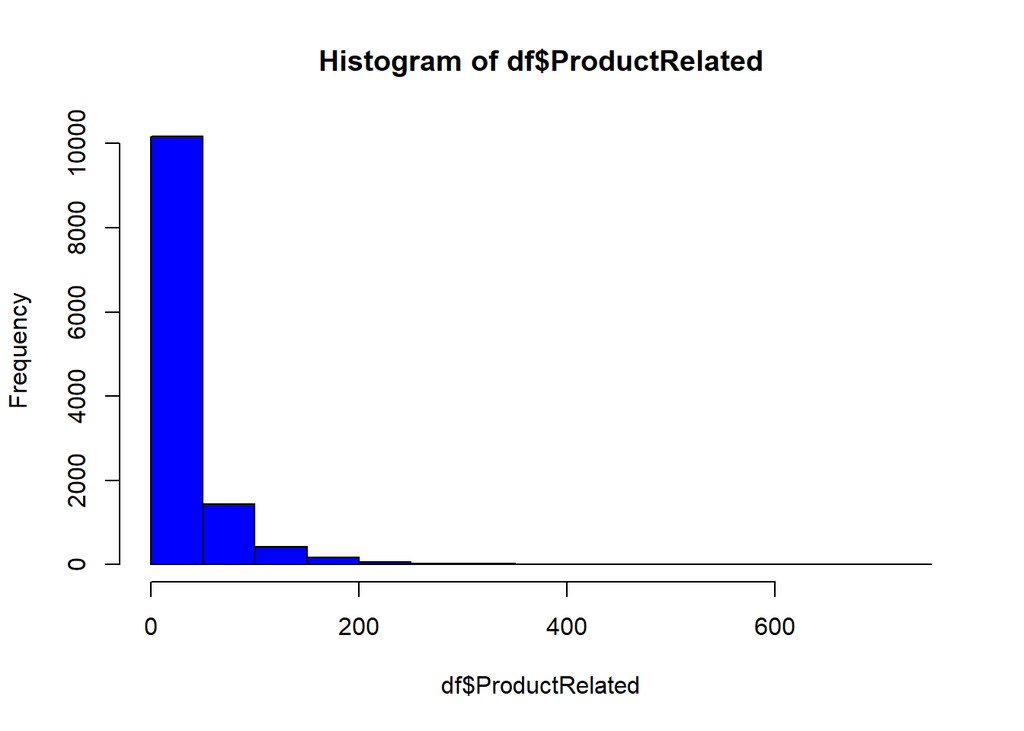

```r
hist(df$ProductRelated, col="blue")
```

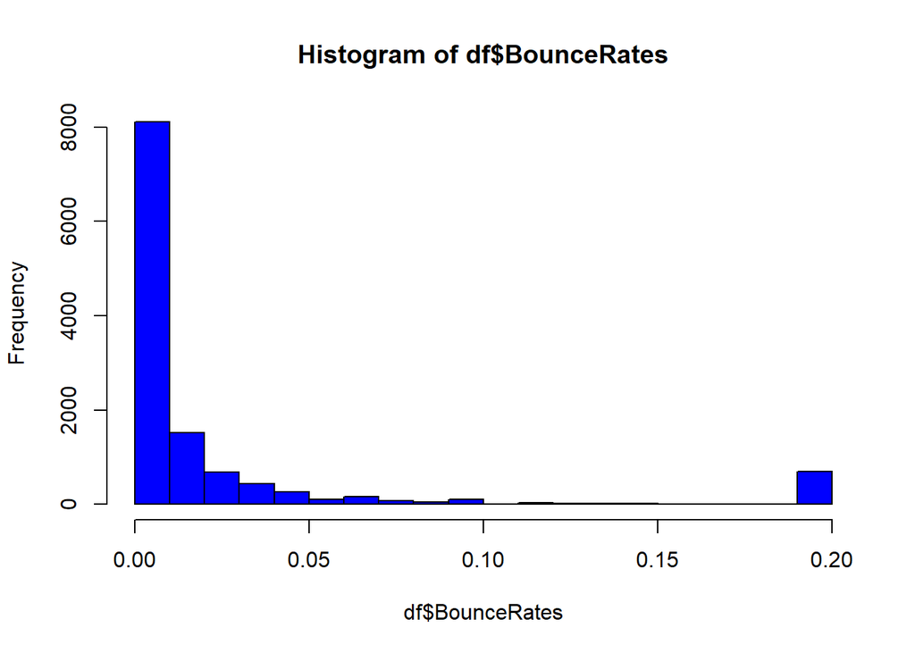

```r
hist(df$BounceRates, col="blue")
```

The histogram shows the percentage of visitors who enter the site from that page and then leave without triggering any other requests to the analytics server during that session

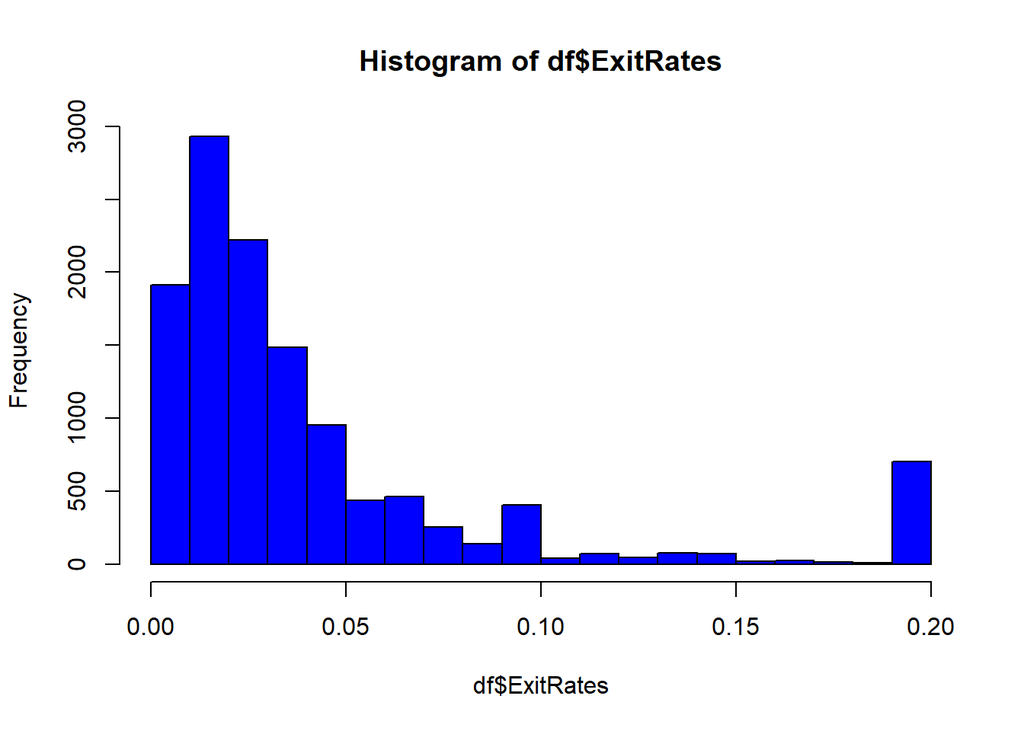

```r
hist(df$ExitRates, col = "blue")
```

**Let’s Visualize visitor’s distribution through out the year**

```r
month <- (df$Month)
month.frequency <- table(month)
month.frequency
```

```
## month
##  Aug  Dec  Feb  Jul June  Mar  May  Nov  Oct  Sep
##  433 1727  184  432  288 1894 3363 2998  549  448
```

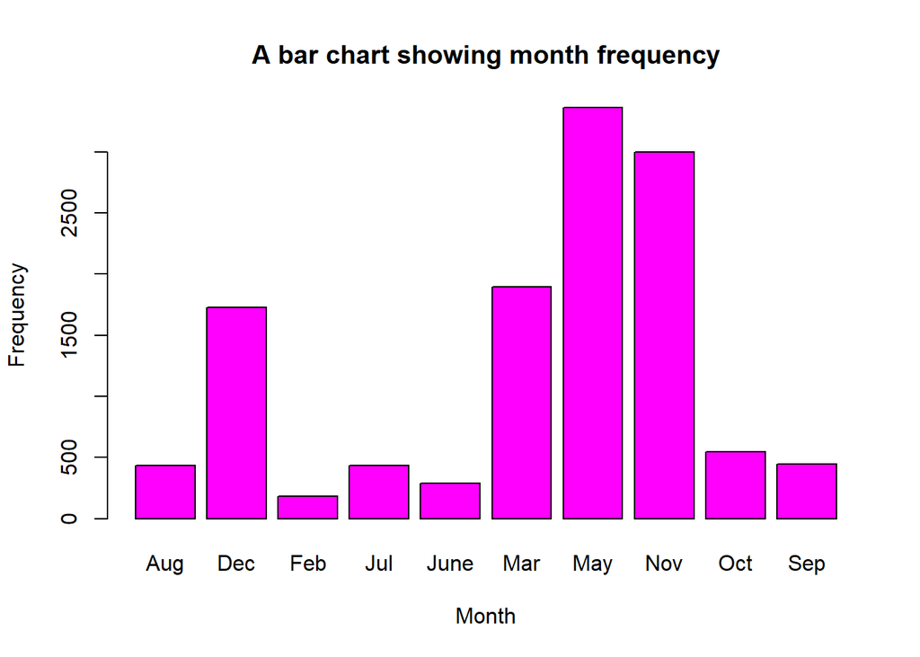

```r
barplot(month.frequency,
  main="A bar chart showing month frequency",
  xlab="Month",
  ylab = "Frequency",
  col=c("magenta")
  )
```

We can see the month with most visitors was may and the least with February.

**Revenue Frequency**

```r
revenue <- (df$Revenue)
revenue.frequency <- table(revenue)
revenue.frequency
```

```
## revenue
## FALSE  TRUE
## 10408  1908
```

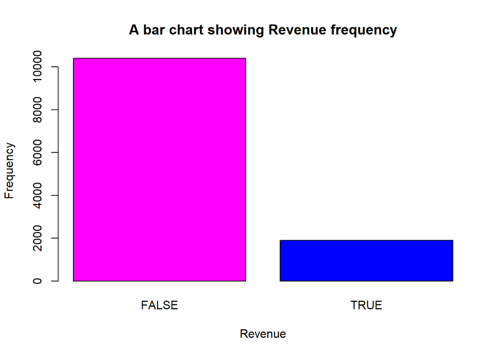

```r
barplot(revenue.frequency,
  main="A bar chart showing Revenue frequency",
  xlab="Revenue",
  ylab = "Frequency",
  col=c("magenta", "blue")
  )
```

We can see that most of the visit were not revenue generating compared to those generating revenue

**Visitor type distribution**

```r
visitor <- (df$VisitorType)
visitor.frequency <- table(visitor)
visitor.frequency
```

```
## visitor
##       New_Visitor             Other Returning_Visitor
##              1694                85             10537
```

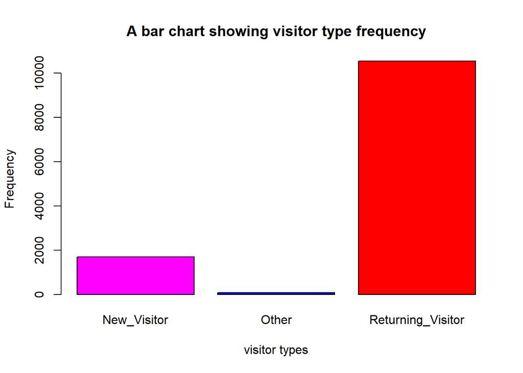

```r
barplot(visitor.frequency,
  main="A bar chart showing visitor type frequency",
  xlab="visitor types",
  ylab = "Frequency",
  col=c("magenta", "blue", "red")
  )
```

Returning visitors were more compared to new visitors and other being the least.

**Week day Distribution**

```r
weekend <- (df$Weekend)
weekend.frequency <- table(weekend)
weekend.frequency
```

```
## weekend
## FALSE  TRUE
##  9451  2865
```

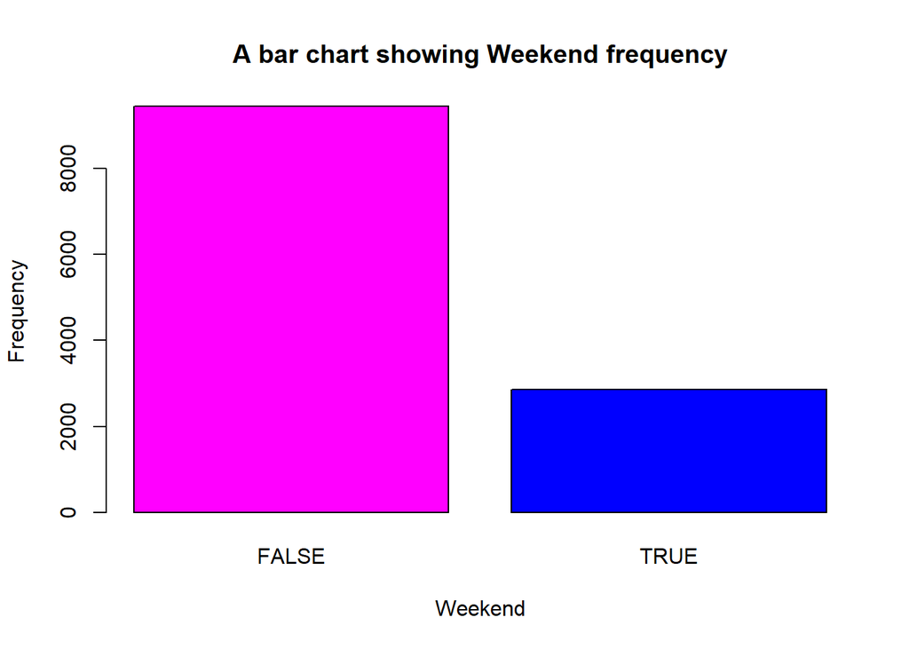

```r
barplot(weekend.frequency,
  main="A bar chart showing Weekend frequency",
  xlab="Weekend",
  ylab = "Frequency",
  col=c("magenta", "blue")
  )
```

Visits on the weekend were less compared to other days.

**Region visitors distribution**

```r
library(janitor)
region <- (df$Region)
region.frequency <- table(region)
region.frequency
```

```
## region
##    1    2    3    4    5    6    7    8    9
## 4774 1134 2402 1179  317  804  761  434  511
```

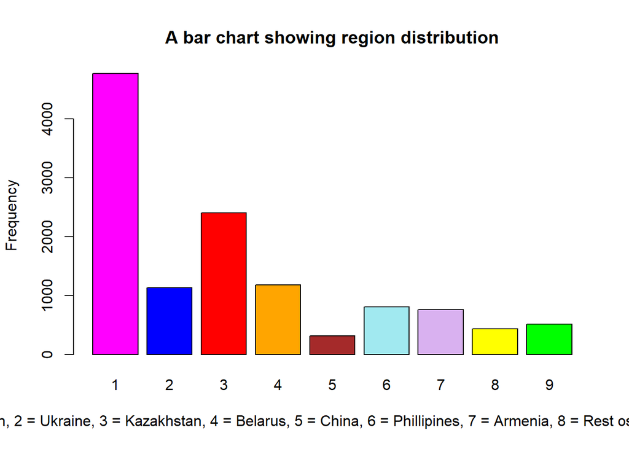

```r
barplot(region.frequency,
  main="A bar chart showing region distribution",
  xlab="Region(1 = Russian, 2 = Ukraine, 3 = Kazakhstan, 4 = Belarus, 5 = China, 6 = Phillipines, 7 = Armenia, 8 = Rest os asia, 9 = Rest of globe)",
  ylab = "Frequency",
  col=c("magenta", "blue", "red", "orange", "brown", "#a1e9f0", "#d9b1f0", "yellow", "green")
  )
```

Clearly shows most of the visitors come from Russia and the least from China.

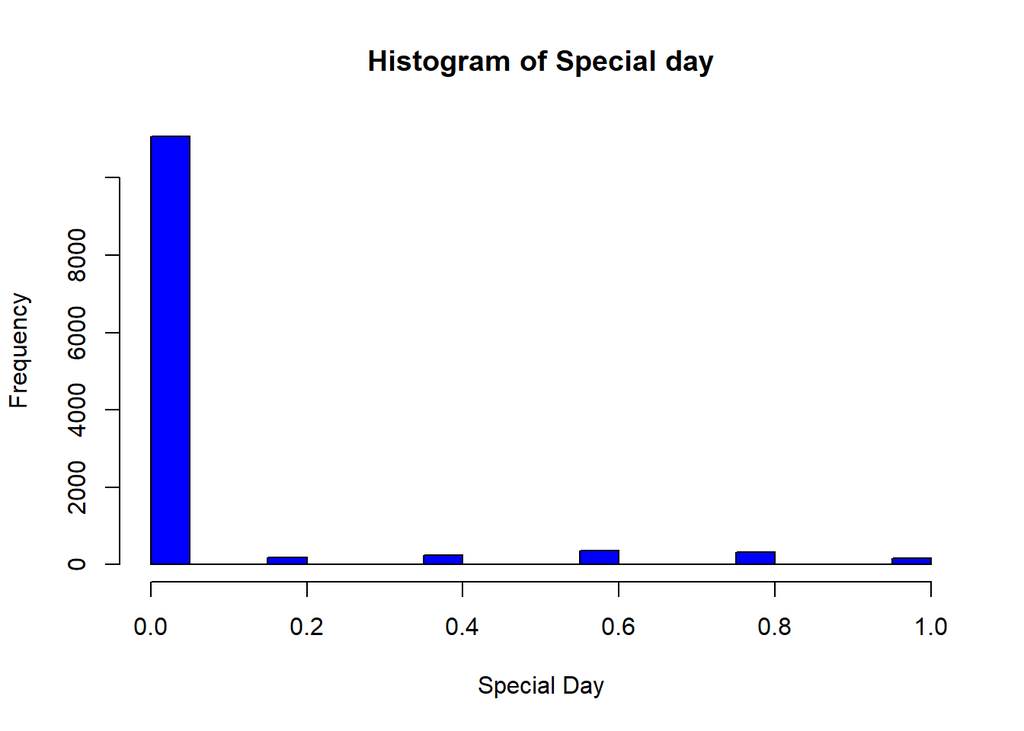

```r
hist((df$SpecialDay),
main = "Histogram of Special day",
     xlab = 'Special Day',
     ylab = 'Frequency',
     col = "blue")
```

The above graph shows the closeness of the site visiting time to a specific special day (e.g. Mother’s Day, Valentine’s Day) in which the sessions are more likely to be finalized with the transaction. when close to a special day this value takes a nonzero value meaning most of the transaction happened when there was no special day close since the highest count is around zero.

**Traffic Type Proportions**

```r
traffic <- (df$TrafficType)
traffic.frequency <- table(traffic)
traffic.frequency
```

```
## traffic
##    1    2    3    4    5    6    7    8    9   10   11   12   13   14   15   16
## 2444 3909 2051 1069  260  444   40  343   42  450  247    1  737   13   37    3
##   17   18   19   20
##    1   10   17  198
```

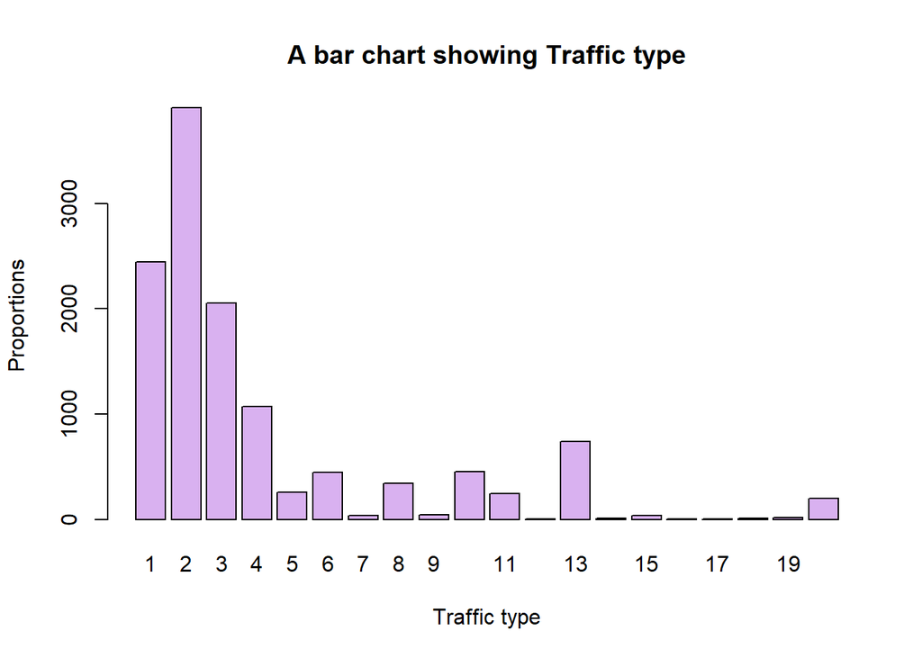

```r
barplot(traffic.frequency,
  main="A bar chart showing Traffic type",
  xlab="Traffic type",
  ylab = "Proportions",
  col=c("#d9b1f0")
  )
```

Traffic type 2 had the highest proportion.

**Operating Systems Proportion**

```r
os <- (df$OperatingSystems)
os.frequency <- table(os)
os.frequency
```

```
## os
##    1    2    3    4    5    6    7    8
## 2582 6593 2552  478    6   19    7   79
```

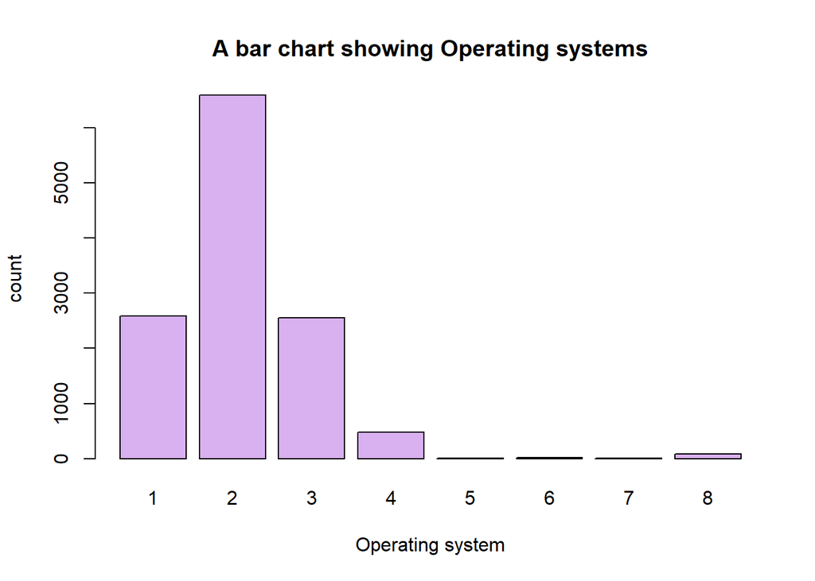

```r
barplot(os.frequency,
  main="A bar chart showing Operating systems",
  xlab="Operating system",
  ylab = "count",
  col=c("#d9b1f0")
  )
```

### **2. Bivariate Analysis**

**Bounce rate Vs Exit Rates in respect to Revenue**

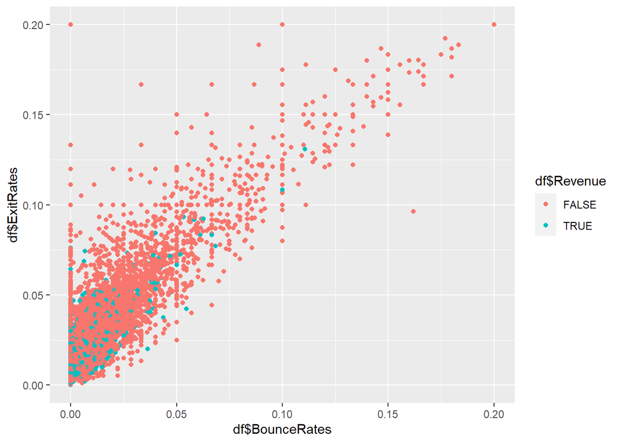

```r
ggplot(df,aes(x=df$BounceRates,y=df$ExitRates,col=df$Revenue))+geom_point(aes(color=df$Revenue))
```

The graph shows revenue generation in respect to Bounce and Exit rates. There is revenue generation when the rates are low but this decreases with increase in the rates.

**Traffic Types vs Revenue**

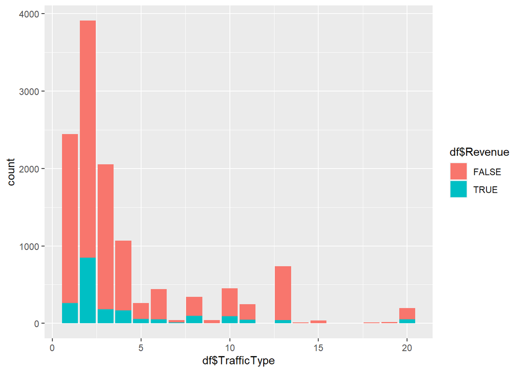

```r
ggplot(df, aes(x = df$TrafficType, fill = df$Revenue)) +
  geom_bar()
```

The graph above shows most of the traffic wasn’t generating revenue.

**Visitor Type vs Revenue**

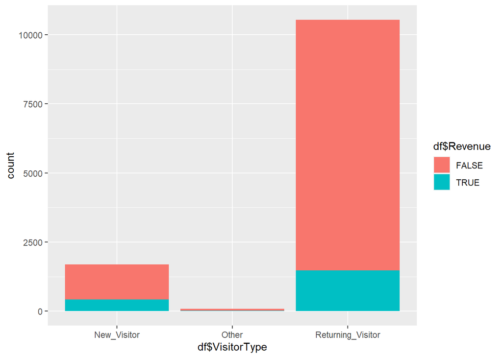

```r
ggplot(df, aes(x = df$VisitorType, fill = df$Revenue)) +
  geom_bar()
```

The number of visitor generating revenue were more on returning visitor compared to new visitors and other visitor types.

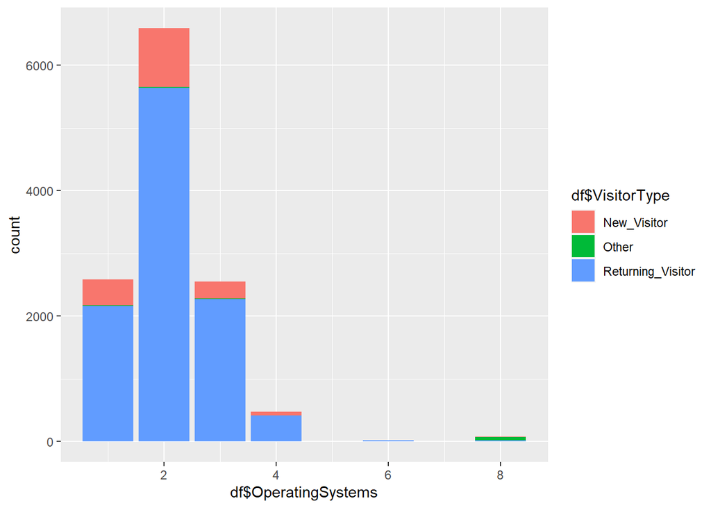

```r
ggplot(df, aes(x = df$OperatingSystems, fill = df$VisitorType)) +
  geom_bar()
```

Most of the visitors were using operating system 2 with an outlier of other visitor using operating system 8.

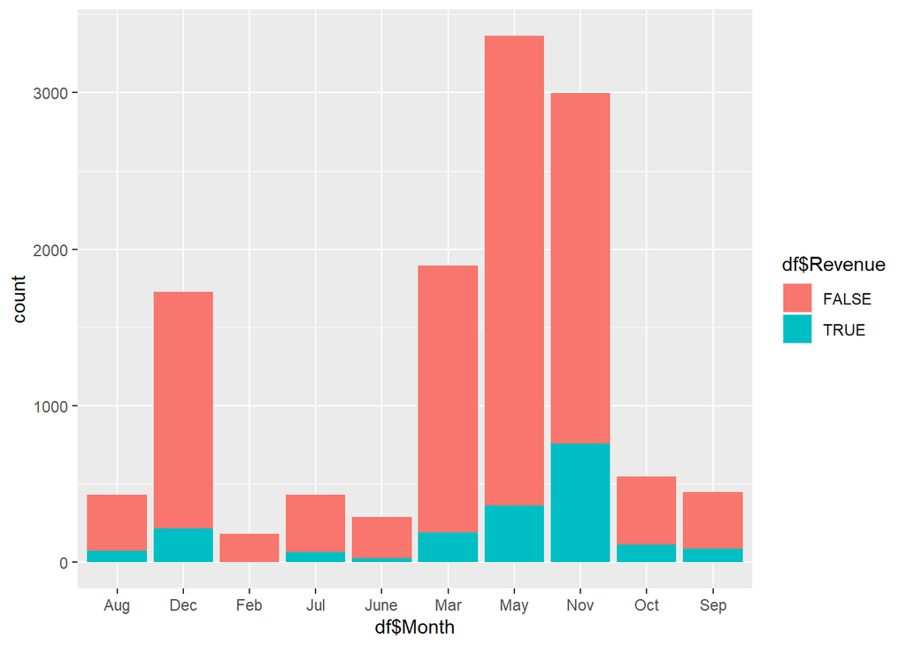

```r
ggplot(df, aes(x = df$Month, fill = df$Revenue)) +
  geom_bar()
```

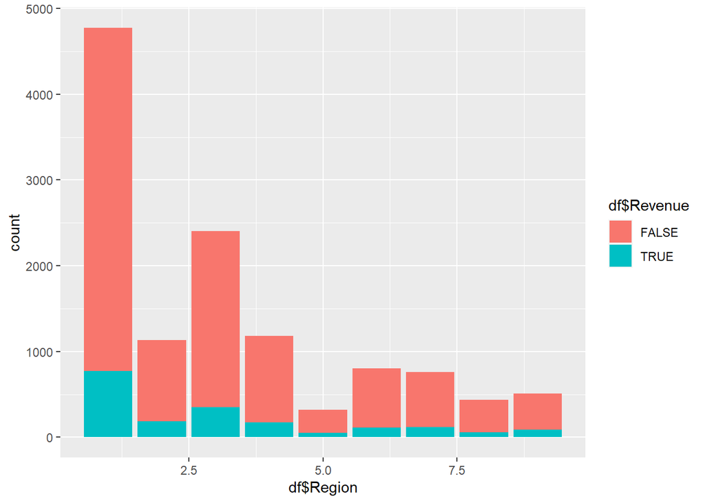

```r
ggplot(df, aes(x = df$Region, fill = df$Revenue)) +
  geom_bar()
```

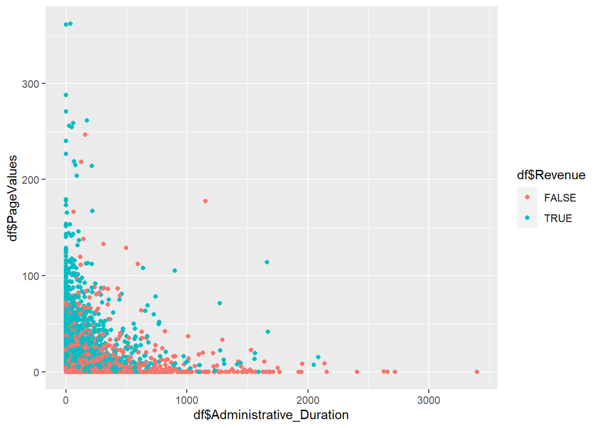

```r
ggplot(df,aes(x=df$Administrative_Duration,y=df$PageValues,col=df$Revenue))+geom_point(aes(color=df$Revenue))
```

The higher the page value the less the administrative duration

### **3. Multivariate Analysis**

```r
head(df)
```

```
##    Administrative Administrative_Duration Informational Informational_Duration
## 1:              0                       0             0                      0
## 2:              0                       0             0                      0
## 3:              0                      -1             0                     -1
## 4:              0                       0             0                      0
## 5:              0                       0             0                      0
## 6:              0                       0             0                      0
##    ProductRelated ProductRelated_Duration BounceRates ExitRates PageValues
## 1:              1                0.000000  0.20000000 0.2000000          0
## 2:              2               64.000000  0.00000000 0.1000000          0
## 3:              1               -1.000000  0.20000000 0.2000000          0
## 4:              2                2.666667  0.05000000 0.1400000          0
## 5:             10              627.500000  0.02000000 0.0500000          0
## 6:             19              154.216667  0.01578947 0.0245614          0
##    SpecialDay Month OperatingSystems Browser Region TrafficType
## 1:          0   Feb                1       1      1           1
## 2:          0   Feb                2       2      1           2
## 3:          0   Feb                4       1      9           3
## 4:          0   Feb                3       2      2           4
## 5:          0   Feb                3       3      1           4
## 6:          0   Feb                2       2      1           3
##          VisitorType Weekend Revenue
## 1: Returning_Visitor   FALSE   FALSE
## 2: Returning_Visitor   FALSE   FALSE
## 3: Returning_Visitor   FALSE   FALSE
## 4: Returning_Visitor   FALSE   FALSE
## 5: Returning_Visitor    TRUE   FALSE
## 6: Returning_Visitor   FALSE   FALSE
```

```r
Monthly_statistics <- df %>% select(Month, Administrative_Duration,
                                    Informational_Duration,
                                    ProductRelated_Duration, PageValues,
                                    ExitRates, BounceRates) %>%
  group_by(Month)%>%summarise_all(mean)
Monthly_statistics
```

```
## # A tibble: 10 x 7
##    Month Administrative_Duration Informational~1 Produ~2 PageV~3 ExitR~4 Bounc~5
##    <chr>                   <dbl>           <dbl>   <dbl>   <dbl>   <dbl>   <dbl>
##  1 Aug                     107.            35.5    1273.   5.94   0.0377  0.0182
##  2 Dec                      78.6           38.1    1111.   6.83   0.0413  0.0201
##  3 Feb                      16.8            2.32    471.   0.890  0.0741  0.0470
##  4 Jul                      78.9           45.5    1218.   4.10   0.0453  0.0247
##  5 June                     59.1           20.5    1213.   3.39   0.0582  0.0351
##  6 Mar                      71.7           30.9     817.   3.99   0.0442  0.0215
##  7 May                      69.5           27.2     982.   5.43   0.0488  0.0268
##  8 Nov                      90.9           43.6    1758.   7.13   0.0382  0.0193
##  9 Oct                     126.            38.7    1117.   8.65   0.0290  0.0118
## 10 Sep                     109.            35.7    1253.   7.56   0.0303  0.0122
## # ... with abbreviated variable names 1: Informational_Duration,
## #   2: ProductRelated_Duration, 3: PageValues, 4: ExitRates, 5: BounceRates
```

- Month with highest administrative duration was October while February had the least.
- Month with highest Informational duration was July while February had the least.
- Month with highest Product related duration was November while February had the least.
- Month with highest Page value was October while February had the least.
- Month with highest Exit rates was February while October had the least.
- Month with highest Bounce rates was February while October had the least.

```r
Region_statistics <- df %>% select(Region, Administrative_Duration,
                                    Informational_Duration,
                                    ProductRelated_Duration, PageValues,
                                    ExitRates, BounceRates) %>%
  group_by(Region)%>%summarise_all(mean)
Region_statistics
```

```
## # A tibble: 9 x 7
##   Region Administrative_Duration Informational~1 Produ~2 PageV~3 ExitR~4 Bounc~5
##    <int>                   <dbl>           <dbl>   <dbl>   <dbl>   <dbl>   <dbl>
## 1      1                    79.7            37.3   1278.    5.91  0.0431  0.0221
## 2      2                    87.0            36.1   1184.    5.92  0.0430  0.0229
## 3      3                    83.1            35.2   1189.    5.35  0.0438  0.0224
## 4      4                    83.3            36.4   1116.    5.82  0.0439  0.0231
## 5      5                    88.5            31.4   1151.    9.28  0.0402  0.0201
## 6      6                    68.7            29.9   1036.    4.81  0.0440  0.0237
## 7      7                    78.8            26.6   1142.    6.26  0.0398  0.0204
## 8      8                    89.6            32.8   1096.    4.26  0.0400  0.0192
## 9      9                    73.0            19.4   1121.    8.94  0.0438  0.0217
## # ... with abbreviated variable names 1: Informational_Duration,
## #   2: ProductRelated_Duration, 3: PageValues, 4: ExitRates, 5: BounceRates
```

# **Modeling**

```r
head(df)
```

```
##    Administrative Administrative_Duration Informational Informational_Duration
## 1:              0                       0             0                      0
## 2:              0                       0             0                      0
## 3:              0                      -1             0                     -1
## 4:              0                       0             0                      0
## 5:              0                       0             0                      0
## 6:              0                       0             0                      0
##    ProductRelated ProductRelated_Duration BounceRates ExitRates PageValues
## 1:              1                0.000000  0.20000000 0.2000000          0
## 2:              2               64.000000  0.00000000 0.1000000          0
## 3:              1               -1.000000  0.20000000 0.2000000          0
## 4:              2                2.666667  0.05000000 0.1400000          0
## 5:             10              627.500000  0.02000000 0.0500000          0
## 6:             19              154.216667  0.01578947 0.0245614          0
##    SpecialDay Month OperatingSystems Browser Region TrafficType
## 1:          0   Feb                1       1      1           1
## 2:          0   Feb                2       2      1           2
## 3:          0   Feb                4       1      9           3
## 4:          0   Feb                3       2      2           4
## 5:          0   Feb                3       3      1           4
## 6:          0   Feb                2       2      1           3
##          VisitorType Weekend Revenue
## 1: Returning_Visitor   FALSE   FALSE
## 2: Returning_Visitor   FALSE   FALSE
## 3: Returning_Visitor   FALSE   FALSE
## 4: Returning_Visitor   FALSE   FALSE
## 5: Returning_Visitor    TRUE   FALSE
## 6: Returning_Visitor   FALSE   FALSE
```

## **K-MEAN Clustering**

Will start by labeling our categorical attribute from categorical to numerical labels and also remove the class label (Revenue)

```r
df1 <- df[, 1:17]

# Change the 'weekend' column's data type to 'factor'
df1$Weekend <- as.factor(df$Weekend)


library(caret)
dummy <- dummyVars("~ .", "Month + OperatingSystems + Browser + Region +
                   TrafficType + VisitorType + Weekend", data=df1)
encoded <- data.frame(predict(dummy, newdata = df1))
df1 <- cbind(df1[ , 1:10], encoded)

# Normalize the values
normal <-function(x) { (x -min(x))/(max(x)-min(x))}
df_norm <- as.data.frame(lapply(df1, normal))

# Preview the top six records
head(df_norm)
```

```
##   Administrative Administrative_Duration Informational Informational_Duration
## 1              0            0.0002941393             0           0.0003920992
## 2              0            0.0002941393             0           0.0003920992
## 3              0            0.0000000000             0           0.0000000000
## 4              0            0.0002941393             0           0.0003920992
## 5              0            0.0002941393             0           0.0003920992
## 6              0            0.0002941393             0           0.0003920992
##   ProductRelated ProductRelated_Duration BounceRates ExitRates PageValues
## 1    0.001418440            1.563122e-05  1.00000000  1.000000          0
## 2    0.002836879            1.016029e-03  0.00000000  0.500000          0
## 3    0.001418440            0.000000e+00  1.00000000  1.000000          0
## 4    0.002836879            5.731448e-05  0.25000000  0.700000          0
## 5    0.014184397            9.824223e-03  0.10000000  0.250000          0
## 6    0.026950355            2.426226e-03  0.07894737  0.122807          0
##   SpecialDay Administrative.1 Administrative_Duration.1 Informational.1
```

[output cut: 55 more lines]

```r
library(dplyr)
```

```r
Result<- kmeans(df_norm, 2, nstart = 25)

# check the number of records in each cluster
Result$size
```

```
## [1] 2865 9451
```

```r
Result$cluster
```

[output not shown]

[output cut: 328 more lines]

```r
table(Result$cluster, df$Revenue)
```

```
##
##     FALSE TRUE
##   1  2366  499
##   2  8042 1409
```

## **Hierarchical Clustering**

Scaling

```r
df <- scale(df_norm)
head(df)
```

```
##      Administrative Administrative_Duration Informational
## [1,]     -0.6975533              -0.4574578    -0.3966145
## [2,]     -0.6975533              -0.4574578    -0.3966145
## [3,]     -0.6975533              -0.4631119    -0.3966145
## [4,]     -0.6975533              -0.4574578    -0.3966145
## [5,]     -0.6975533              -0.4574578    -0.3966145
## [6,]     -0.6975533              -0.4574578    -0.3966145
##      Informational_Duration ProductRelated ProductRelated_Duration BounceRates
## [1,]             -0.2450294     -0.6914734              -0.6247671  3.67247746
## [2,]             -0.2450294     -0.6689966              -0.5913358 -0.45743910
## [3,]             -0.2521304     -0.6914734              -0.6252895  3.67247746
## [4,]             -0.2450294     -0.6689966              -0.6233742  0.57504004
## [5,]             -0.2450294     -0.4891823              -0.2969835 -0.04444744
## [6,]             -0.2450294     -0.2868911              -0.5442099 -0.13139305
##       ExitRates PageValues SpecialDay Administrative.1
```

[output cut: 62 more lines]

computing the Euclidean distance between observations,

```r
d <- dist(df, method = "euclidean")
```

We then hierarchical clustering using the Ward’s method

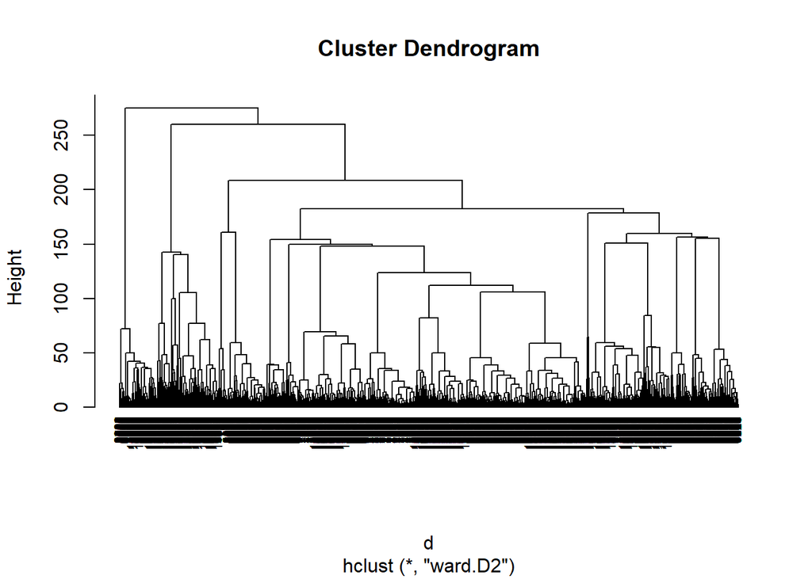

```r
res.hc <- hclust(d, method = "ward.D2" )
plot(res.hc, cex = 0.6, hang = -1)
```

```r
cut <- cutree(res.hc, k = 2)
cut
```

[output not shown]

[output cut: 328 more lines]

```r
table(cut)
```

```
## cut
##     1     2
## 11563   753
```

**Conclusion** Both K-mean and Hierarchical Clustering were unable to predict correctly if Revenue will be true or false. DBSCAN is not stable for this data since it has high dimensional.

**Recommendation:** Dimensional reduction is the best option to get better results